# PROYECTO FINAL

Econometría II

2022-05-23

# **Integrantes:**

- Arturo Balam Miranda Hernández
- Luis Abraham García Figueroa
- Marco Antonio Percastre Sotelo

#TEMA

# **APLICACIÓN DE LA METODOLOGÍA BOX-JENKINS NO ESTACIONAL PARA MODELAR UN ARIMA Y PRONOSTICAR EL PRECIO DE LAS ACCIONES DE TWITTER.**

#INTRODUCCIÓN

Se pretende mostrar una herramienta estadística de análisis univariante para la predicción de una empresa que cotice en un mercado continuo y el precio objetivo de la compañia, es decir, su acción. La aplicación de éste modelo es útil para la valoración de acciones y empresas, así como la predicción de la volatilidad. Su única desventaja es que al ser un modelo que toma en cuenta una única variable no existe posibilidad de relacionarla con mas variables que afectan al valor de las acciones de una empresa, aún así, este modelo es demasiado útil cuando se quiere una predicción a corto plazo debido a su aplicación estadística, lo que lo hace un modelo muy útil para realizar predicciones de valores bursátiles.

La diferencia entre proceso y modelo. Un proceso es lo real, del cual se desconoce su mecanismo generador. Un modelo es la imitación o representación del modelo (Pankratz 1983).

Los procesos se clasifican en estacionarios y no estacionarios. Los procesos estacionarios no presentan cambios sistemáticos en la media ni en la varianza, es decir, son constantes con el tiempo, con esto se dice que un proceso estacionario es estable, miestras que, por otro lado, los procesos no estacionarios si presentan cambios en la media y la varianza, con esto se dice que la serie es inestable en el tiempo.

Los modelos $ARIMA$: se pueden aplicar con datos discretos (números enteros) y contínuos (números fraccionarios); necesitan de un numero mínimo de 50 observaciones (Box-Jenkins); se caracterizan porque su ACF decrece muy lentamente; se asume que las perturbaciones aleatorias presentes en la serie son independientes entre sí, no existe ninguna correlacion y por lo tanto ningún patrón modelable; es un modelo desarrollado con combinaciones de proceso Autoregresivos (AR), Integrados (I) y Media Movil (MA).

$ACF$, Llamada como Función de Autocorrelacion, mide la correlación entre dos variables separadas por $k$ periodos y mide el grado de asociación lineal que existe entre dos variables del mismo proceso estocástico. Identifica el proceso Media Movil $MA$ y nos da información de su orden $q$.

$PACF$, Llamada como Función de Autocorrelacion Parcial, mide la correlacion entre dos variables separadas por $k$ periodos cuando no se considera la dependencia creada por los retardos intermedios existentes entre ambas, y mide la autocorrelación que existe entre dos variables $k$ periodos descontando los posibles efectos debido a variables intermedias. Identifica valores del proceso Autoregresivo $AR$ y nos da información de su orden $p$.

$DFA$, Llamada Dickey-Fuller Aumentada, es una prueba estadística de raices unitarias, permite detectar la existencia o no existencia de éstas raices unitarias y determina el comportamiento del proceso estocástico.

$Akaike$, Nos permite identificar un modelo de manera mas sencilla y automática. Es el Criterio de Información Akaike, la solución dada es elegir como función de perdida (Criterios de Especificacion) el mínimo de criterio de información AIC. Permite interpretar la distancia entre dos distribuciones a partir de la log-verosimilitud de un modelo. Es hallar una función perdida que al ser minimizada permita obtener el modelo que mejor se ajusta a los datos.

Metodología Box-Jenkins No estacional, es la metodología mas usada y conocida propuesta por G.E.P. Box y G.M. Jenkins en la decada de 1970 en su obra $Time Series Analisis: Forecasting and Control$, utilizada para la predicción de variables económicas. Esto con el motivo de identificar, modificar y ajustar los modelos ARIMA adecuados debido a que durante ese periodo, en el que había estanflación, dejaba sin capacidad explicativa a los modelos econométricos de carácter estructural. Esta metodología se basa en 5 etapas principales: 1. Estacionariedad 2. Identificación 3. Estimación 4. Evaluación 5. Pronóstico

#TABLA DE PRECIOS DE LAS ACCIONES DE TWITTER

|  | Date | Open | High | Low | Close | Adj Close | Volume |
| --- | --- | --- | --- | --- | --- | --- | --- |
| 1 | 2020-05-18 | 29.700001 | 30.290001 | 29.559999 | 29.639999 | 29.639999 | 15772400 |
| 2 | 2020-05-19 | 29.700001 | 30.35 | 29.33 | 29.879999 | 29.879999 | 17386200 |
| 3 | 2020-05-20 | 30.5 | 32.349998 | 30.450001 | 32.23 | 32.23 | 26955500 |
| 4 | 2020-05-21 | 32.099998 | 32.610001 | 31.389999 | 32.34 | 32.34 | 22881700 |
| 5 | 2020-05-22 | 32.380001 | 32.77 | 31.780001 | 32.619999 | 32.619999 | 13310700 |
| 6 | 2020-05-26 | 33.599998 | 34.27 | 33.360001 | 34.009998 | 34.009998 | 20489300 |
| 7 | 2020-05-27 | 33.630001 | 34 | 32.240002 | 33.07 | 33.07 | 24550900 |
| 8 | 2020-05-28 | 31.5 | 32.68 | 31.32 | 31.6 | 31.6 | 37254900 |
| 9 | 2020-05-29 | 31.559999 | 31.610001 | 30.290001 | 30.969999 | 30.969999 | 39413300 |
| 10 | 2020-06-01 | 31.059999 | 32.099998 | 30.84 | 31.889999 | 31.889999 | 14583600 |

[output cut: 495 more lines]

#INFORMACIóN DE LA VARIABLE A UTILIZAR

De la tabla anterior, la variable utilizada para este proyecto recoge el precio de cierre de cada dia en los últimos dos años, del 17 de mayo del 2020 al 17 de mayo del 2022. El tamaño muestral de la serie debe ser igual o mayor a 50 observaciones, como se indicó anteriormente, para este proyecto el total de observaciones es de 505, por lo que nos lanzara resultados muy efectivos del precio en dólares. Los datos del precio fueron obtenidos de $finance.yahoo.com$ y corresponde a las acciones de Twitter.

#GRÁFICA DE LA SERIE TEMPORAL, Aquí seguimos con el punto uno de Estacionariedad de la metodología.

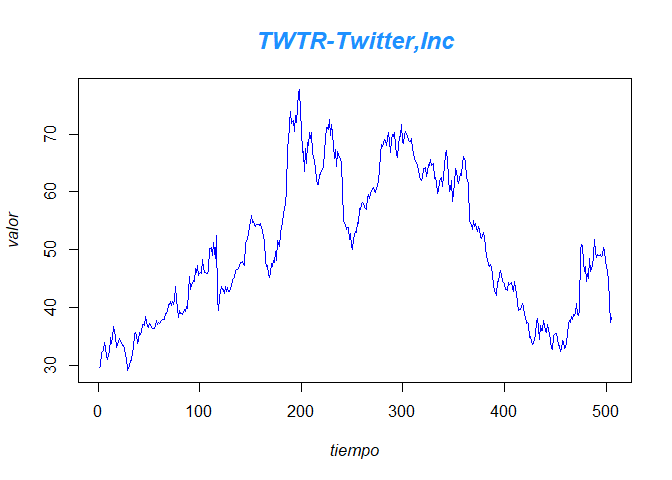

A simple vista podemos ver que el proceso es no estacionario, es decir, es inestable, debido a que cuando se llega a una apreciación no fluctúa en torno a una media y lo mismo ocurre durante todo el comportamiento de la serie de tiempo. Para estar más seguros de sí la serie es estacionaria o no, vamos a realizar la $ACF$, $PACF$ y la prueba estadística de $DFA$.

ACF:

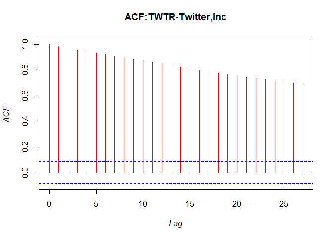

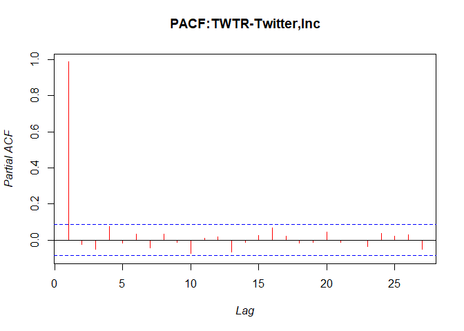

```
##
## Partial autocorrelations of series 'X_t', by lag
##
##     1
## 0.987
```

Nuevamente podemos verlo con claridad, el resultado del proceso en el $ACF$ y $PACF$ es no estacionario, esto se observa en los respectivos gráficos. La $ACF$ decrece con una lentitud extrema sin llegar a tener un valor a $0$, por lo que los valores de la serie temporal no son estacionarios, y la $PACF$ presenta un valor muy próximo a 1 de $0.987$ que es indicativo de la precencia de raices unitarias. Por lo que ahora vamos a realizar la prueba de $DFA$ para confirmarlo estadísticamente.

PRUEBA DE DFA: Vamos a presentar la siguiente prueba de hipótesis.

$H_0$ No estacionaria y con raíces unitarias $\rho=$ 0

$H_1$ Estacionaria sin raíces unitarias $\rho<$ 0

```
##
##  Augmented Dickey-Fuller Test
##
## data:  X_t
## Dickey-Fuller = -1.6579, Lag order = 7, p-value = 0.7231
## alternative hypothesis: stationary
```

Haciendo la prueba estadística de $DFA$ nos sacó un $p-value=0.7231$ y dado que tenemos una $Sig.=0.05$ se observa que $p-value>Sig.$, es decir, $0.7231>0.05$, entonces decimos que tenemos evidencia estadística para aceptar la $H_0:$ que nos dice que es no estacionario y que tiene raíces unitarias. Vemos también que tiene un orden de retraso igual a 7.

Otra forma de ver si es estacionario o no estacionario:

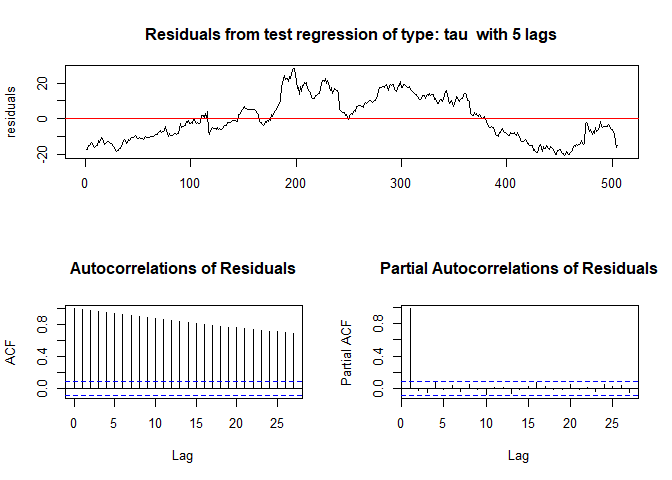

```
##
## Title:
##  KPSS Unit Root Test
##
## Test Results:
##   NA
##
## Description:
##  Mon May 23 11:20:19 2022 by user: Luis Abrahám
```

NOTA: la realidad es que las series de tiempo normalmente no se comportan de manera estable, es decir, no son procesos estocásticos estacionarios.

Y dado que tenemos un proceso estocástico no estacionario y la precencia de raíces unitarias procedemos a la diferenciación con la función $diff()$ de R y veamos como se ve gráficamente:

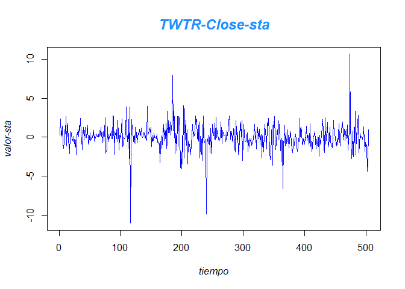

La función $ndiffs()$ nos permitirá encontrar el número de primeras diferencias necesarias para que la serie de tiempo sea estacionaria, para este caso en particular, nos dice que solo es $1$ el número de diferencias para hacer que nuestro proceso sea estacionario, como se ve a continuación:

```r
ndiffs(X_t) #determinar el n?mero de primeras diferencias necesarias para que las series temporales no sean estacionales
```

```
## [1] 1
```

La integración que es el proceso de estabilización y diferenciación, por medio del parámetro $d$ dentro del modelo $ARIMA(p,d,q)$. Para nuestro proceso de serie de tiempo es $d=1$.

Veamos la $ACF$ y $PACF$ de la serie con estacionariedad aplicando la diferenciación: $(TWTR-Close-Sta)$.

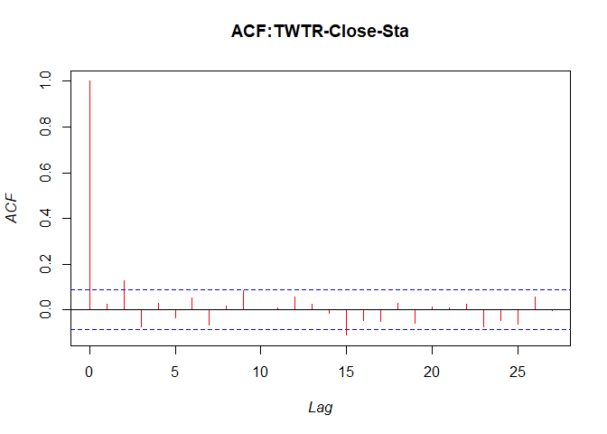

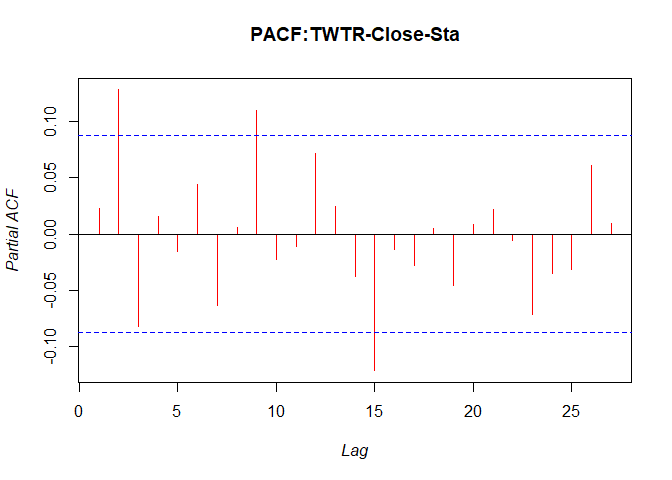

```
##
## Partial autocorrelations of series 'X_tsta', by lag
##
##     1
## 0.022
```

Aplicando la otra forma de ver si es estacionario o no estacionario:

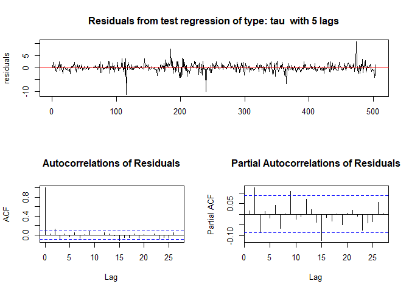

```
##
## Title:
##  KPSS Unit Root Test
##
## Test Results:
##   NA
##
## Description:
##  Mon May 23 11:20:19 2022 by user: Luis Abrahám
```

Logramos ver que ya es estacionaria, es decir, es estable nuestra nueva serie $(TWTR-Close-Sta)$, porque podemos observar como la serie ya estaría pasando por una media constante igual a 0. Una vez que logramos la estacionaridad ya podemos realizar la modelación $ARIMA$, por lo que ahora vamos a identificar el modelo mas probable que mejor se adapta.

Al hacer las $ACF$ y la $PACF$ obtenimos los posibles candidatos para el modelo, y con esto hicimos el punto dos de la metodologia que es la Identificación.

#CRITERIO DE INFORMACIÓN AKAIKE (AIC)

Aquí es el punto tres de la metodología, la Estimación, sacando la $ACF$ y $PACF$ de la serie ya estacionaria y estable $(TWTR-Close-Sta)$ podemos identificar los posibles candidatos para nuetro modelo $ARIMA(p,d,q)$. Los posibles candidatos son $p=3$, $d=1$ y $q=1$, asi que nuestro modelo quedaría de la forma $ARIMA(3,1,1)$. Cabe mencionar que $d=1$ porque fue el número de diferenciación para suavizar y hacer estacionaria y estable nuestro proceso.

NOTA: los posibles candidatos se aplican a la serie de tiempo del proceso inicial.

```
##    p d q      AIC
## 12 2 1 1 1925.100
## 15 3 1 0 1925.591
## 11 2 1 0 1926.951
## 16 3 1 1 1927.100
## 3  0 1 0 1931.608
## 7  1 1 0 1933.351
## 4  0 1 1 1933.404
## 8  1 1 1 1933.818
## 14 3 0 1 1934.567
## 13 3 0 0 1936.206
## 10 2 0 1 1940.163
## 5  1 0 0 1941.522
## 9  2 0 0 1943.175
## 6  1 0 1 1943.251
## 2  0 0 1 3388.603
## 1  0 0 0 3972.278
```

```
## [1] 1925.1
```

El mejor candidato para el modelo $(ARIMA(p,d,q)$ es aquel que tiene el menor valor de Criterio de Información Akaike (AIC), para este caso, el mejor candidato esta de la forma $(ARIMA(2,1,1)$ con un valor de $AIC=1925.100$.

Realizamos la modelación para el mejor candidato que es un $ARIMA(2,1,1)$ con nuestra serie de tiempo inicial:

```
##
## Call:
## arima(x = X_t, order = c(2, 1, 1))
##
## Coefficients:
##           ar1     ar2     ma1
##       -0.5320  0.1409  0.5653
## s.e.   0.2003  0.0470  0.2007
##
## sigma^2 estimated as 2.627:  log likelihood = -958.55,  aic = 1925.1
##
## Training set error measures:
##                      ME     RMSE     MAE           MPE     MAPE      MASE
## Training set 0.01536849 1.619141 1.09168 -0.0009394362 2.211662 0.9907922
##                       ACF1
## Training set -4.432572e-05
```

#SIGNIFICANCIA DE LOS COEFICIENTES

Los parámetros $\theta$ y $\rho$ del modelo propuesto deben cumplir con los siguientes requerimientos: 1. Un modelo con parsimonia ajusta la información disponible sin usar coeficientes innecesarios. 2. El modelo debe ser estacionario e inversible. 3. Los coeficientes del modelo deben ser estadisticamente significativos.

Procedemos a obtener la significancia de los coeficientes del modelo, para saberlo es necesario realizar los intervalos de confianza para los coeficientes de $ar1$, $ar2$ y $ma1$. Con un intervalo de confianza del 0.95 y una $Sig.=0.05$.Los coeficientes son los siguientes: $ar1=-0.5320$ $ar2=0.1409$ $ma1=0.5653$

```
##          2.5 %     97.5 %
## ar1 -0.9245531 -0.1395157
```

```
##          2.5 %    97.5 %
## ar2 0.04875502 0.2331224
```

```
##         2.5 %    97.5 %
## ma1 0.1720642 0.9586187
```

```
##           2.5 %     97.5 %
## ar1 -0.92455305 -0.1395157
## ar2  0.04875502  0.2331224
## ma1  0.17206423  0.9586187
```

Construyendo los intervalos de confianza podemos observar que los coeficientes para $ar1$, $ar2$ y $m1$ se encuentran dentro de los intervalos de confianza por lo que decimos que son significativos.

4. El modelo debe proporcionar un adecuado ajuste.

#LA ECUACIÓN DEL MODELO QUEDA DE LA SIGUIENTE EXPRESIÓN: La ecuación del modelo esta de la forma: $(1-\alpha_{1}B-\alpha_{2}B^{2}-...-\alpha_{p}B^{p})(1-B)^{d}X_{t}=c+(1+\theta_{1}B+\theta_{2}B^{2}+...+\theta_{q}B^{q})W_{t}$

Donde B es el operador rezago: $BX_{t}=X_{t-1}$, $B^{2}X_{t}=X_{t-2}$, … , $B^{n}X_{t}=X_{t-n}$

La ecuación de nuestro modelo quedó de la forma: $(1-(-0.5320B)-0.1409B^{2})X_{t}=(1+0.5653)W_{t}$ $(1+0.5320B-0.1409B^{2})X_{t}=(1+0.5653)W_{t}$ $X_{t}+0.5320X_{t}-0.1409B^{2}X_{t}=0.5653W_{t}+W_{t}$ $X_{t}=-0.5320BX_{t}+0.1409B^{2}X_{t}+0.5653W_{t}+W_{t}$
$$X_{t}=-0.5320X_{t-1}+0.1409X_{t-2}+0.5653W_{t-1}+W_{t}$$

#GRÁFICA DE LOS RESIDUOS DEL MODELO Aquí es el punto cuatro de la metodología, la Evaluación. Un modelo estadísticamente adecuado es aquel cuyos residuales son independientes entre sí, es decir, los residuales son completamente aleatorios (4.Modelación ARIMA, UNAM).

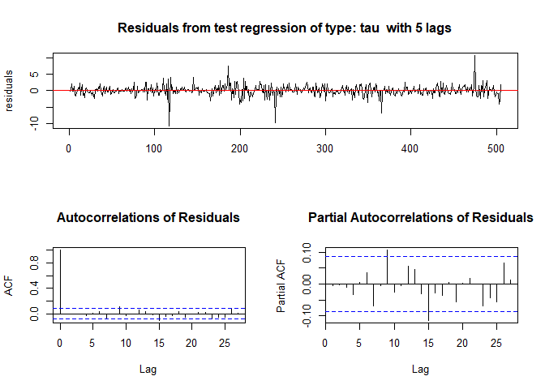

```
##
## Title:
##  KPSS Unit Root Test
##
## Test Results:
##   NA
##
## Description:
##  Mon May 23 11:20:21 2022 by user: Luis Abrahám
```

Los gráficos indican visualmente que no hay correlación entre los residuos y que se distribuyen de forma independiente. Para estar seguro de esto, hay que verificarlo estadísticamente con una prueba de Ljung-Box.

#PRUEBA DE LJUNG-BOX

Pero antes hay que hacer un diagnóstico para saber si el modelo es bueno:

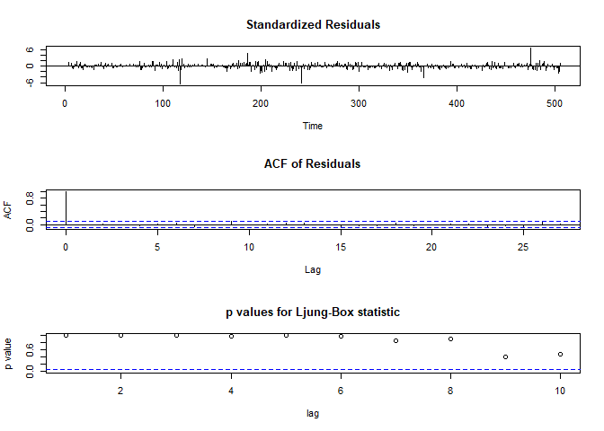

Aquí destaca el gráfico de los valores p para el estadístico de Ljung-Box que nos ayuda a identificar si hay o no ruido blanco. Esta es una manera gráfica de esta prueba, la línea cortada azul tiene un valor igual a 0.05, mientras que los puntos son los valores de p, visualmente vemos que hay ruido blanco en el modelo y que este se ajusta bien. Para verificarlo haremos la prueba estadística, las cuales son las siguientes hipótesis:

$H_0$ Hay Ruido Blanco y el modelo se ajusta bien $p valor >$ 0.05

$H_1$ No hay Ruido Blanco y el modelo no se ajusta bien $\rho <$ 0

```
##
##  Box-Ljung test
##
## data:  residuals(modelo1)
## X-squared = 9.9811e-07, df = 1, p-value = 0.9992
```

Veamos gráficamente que el error tiene media igual a 0:

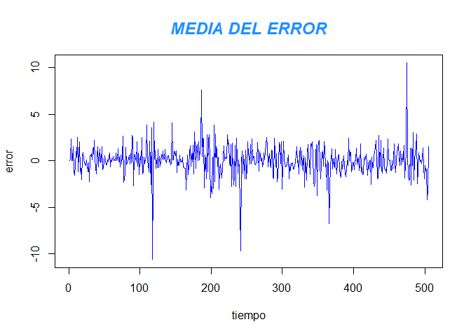

#PRONÓSTICO Es el punto 5 de la metodología, aquí se quiere hacer un pronóstico del valor y comportamiento de los siguientes 10 dias del cierre de las acciones de $TWTR-Twitter,Inc$ en el mercado financiero:

```
##     Point Forecast    Lo 80    Hi 80    Lo 95    Hi 95
## 506       38.23135 36.15428 40.30842 35.05474 41.40795
## 507       38.40959 35.42285 41.39633 33.84176 42.97741
## 508       38.30226 34.46937 42.13516 32.44035 44.16417
## 509       38.38448 33.92688 42.84209 31.56717 45.20180
## 510       38.32561 33.27286 43.37837 30.59809 46.05313
## 511       38.36852 32.81430 43.92274 29.87408 46.86297
## 512       38.33740 32.30274 44.37205 29.10819 47.56660
## 513       38.36000 31.89440 44.82561 28.47172 48.24829
## 514       38.34359 31.46449 45.22269 27.82291 48.86426
## 515       38.35551 31.09295 45.61806 27.24839 49.46263
```

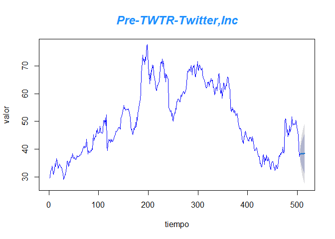

La gráfica significa que existe un 80 por ciento de probabilidad de que los valores futuros del modelo estén dentro del área oscura sombreada y el 95 por ciento de probabilidad de que estén en el area clara sombreada.

#RAÍCES DEL MODELO Gráficamente así se ven las raíces:

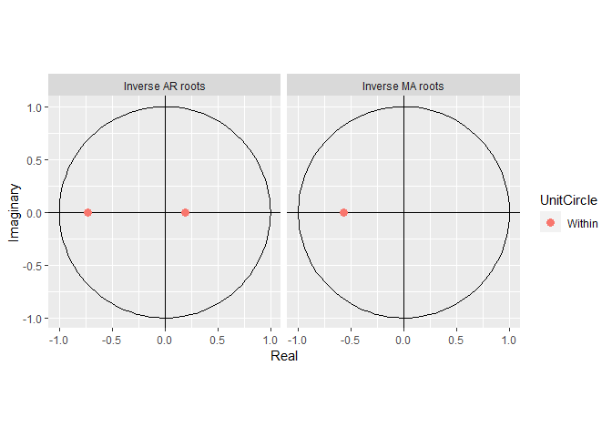

Si las raíces están afuera (o muy cerca) del círculo unitario, el modelo sera numéricamente inestable y no será adecuado para hacer un pronóstico. Para nosotros, podemos ver las raíces unitarias que se encuentran dentro del círculo unitario, por lo qué podemos decir que es adecuado para hacer pronósticos.

#RESUMEN

Es importante tener en cuenta que debe haber estacionariedad en la serie de tiempo para realizar un $ARIMA$, por lo que es fundamental utilizar la diferenciación en el proceso original para suavizar el proceso no estacionario y así poder analizar de mejor manera la serie de tiempo. Se recomienda seguir la metodología de las 5 etapas de Box-Jenkins para modelar un ARIMA adecuado que consisten en: 1) Estacionariedad; 2) Identificación; 3) Estimación; 4) Evaluación; y 5) Pronóstico. La metodología fue hecha por George E.P. Box y Gwilyn M. Jenkins, quienes se interesaron en estudiar las series temporales porque se dieron cuenta de la importancia que tenía en la economía y en los negocios, su principal enfoque fue solucionar los problemas de perturbaciones, por lo que dió lugar a la publicación de su obra en 1970 titulada $Time Series Analysis: Forecasting and Control$, los modelos ARIMA tienen aplicación en los negocios, economía, medicina y en cualquier otra ciencia, por lo que sí te interesa conocer mas sobre las series temporales te recomendamos este libro debido a que tiene referencias invaluables para estadísticos aplicados, ingenieros y especialistas financieros.

En este trabajo aplicamos la metodología en relación con lo aprendido durante el curso, por lo que aplicar y comprender la metodología puede dar mayor sencillez al conocer las series de tiempo y, así mismo, ser mas útil en la modelación de un ARIMA univariante.

Con lo que respecta al desarrollo del trabajo, debemos mencionar que la predicción que se estima es aplicable para predecir el valor y comportamiento de la serie a corto plazo debido a su sustento estadístico. Las herramientas estadísticas aplicadas durante las etapas de la metodología dan importancia y seguimiento para realizar una modelación adecuada y así realizar predicciones.

#REFERENCIAS

(s.f.). Procesos Integrados. En C. 5.

A Unexpected Route to Time Series. (30 de OCTOBER de 1989). This Weeks Citation Classic, pág. 1.

Campos, F. (2 de Noviembre de 2018). Analisis de series temporales en R. ARIMA. DIEGO CALVO.

Hernandez, S. (2015). Los modelos ARIMA univariantes . Analisis de Series de Tiempo (pags. 1-32). Mexico: CEPAL.

Lopez, A. M. (2011). ESTUDIO DEL AIC Y BIC EN LA SELECCI?N DE MODELOS DE VIDA CON DATOS CENSURADOS. Guanajuato, Gto.: CIMAT.

Martinez, E. C. (14 de Mayo de 2019). EJERCICIO 6 Y 8. RPubs by Rstudio.

Mauricio, J. A. (2007). Análisis de Series Temporales. SERIES TEMPORALES (pags. 1-132). Madrid, España: Universidad Complutense de Madrid.

Modelacion ARIMA. (s.f.). 41-78.

PRELIMINAR, L. U. (2007). A. B. Iglesias, J. T. Pruñunosa y N. M. Llavines. Escuela Universitaria Caixa Terrassa , 1-13.